# Reproducible Analysis assesment 2

## Analysis of impact of types of weather events based on NOOA’s storm database.

In this report we analyse impact of weather events on public health and economy. This report based on data provided U.S. National Oceanic and Atmospheric Administration’s (NOAA). According to this data the most harmful for economy weather event is flood and the most dangerous for public health is tornado.

# Data processing

Check archive and dowload if it needs:

```r
if (!file.exists("repdata-data-StormData.csv.bz2")){
  download.file("https://d396qusza40orc.cloudfront.net/repdata%2Fdata%2FStormData.csv.bz2",
                "repdata-data-StormData.csv.bz2")
}
```

Read the data:

```r
storm_data <- read.csv(bzfile("repdata-data-StormData.csv.bz2"), header=TRUE, stringsAsFactors = FALSE)
```

Run some basis analysis of data:

```r
head(storm_data)
```

```
##   STATE__           BGN_DATE BGN_TIME TIME_ZONE COUNTY COUNTYNAME STATE
## 1       1  4/18/1950 0:00:00     0130       CST     97     MOBILE    AL
## 2       1  4/18/1950 0:00:00     0145       CST      3    BALDWIN    AL
## 3       1  2/20/1951 0:00:00     1600       CST     57    FAYETTE    AL
## 4       1   6/8/1951 0:00:00     0900       CST     89    MADISON    AL
## 5       1 11/15/1951 0:00:00     1500       CST     43    CULLMAN    AL
## 6       1 11/15/1951 0:00:00     2000       CST     77 LAUDERDALE    AL
##    EVTYPE BGN_RANGE BGN_AZI BGN_LOCATI END_DATE END_TIME COUNTY_END
## 1 TORNADO         0                                               0
## 2 TORNADO         0                                               0
## 3 TORNADO         0                                               0
## 4 TORNADO         0                                               0
## 5 TORNADO         0                                               0
## 6 TORNADO         0                                               0
##   COUNTYENDN END_RANGE END_AZI END_LOCATI LENGTH WIDTH F MAG FATALITIES
```

[output cut: 20 more lines]

```r
str(storm_data)
```

```
## 'data.frame':    902297 obs. of  37 variables:
##  $ STATE__   : num  1 1 1 1 1 1 1 1 1 1 ...
##  $ BGN_DATE  : chr  "4/18/1950 0:00:00" "4/18/1950 0:00:00" "2/20/1951 0:00:00" "6/8/1951 0:00:00" ...
##  $ BGN_TIME  : chr  "0130" "0145" "1600" "0900" ...
##  $ TIME_ZONE : chr  "CST" "CST" "CST" "CST" ...
##  $ COUNTY    : num  97 3 57 89 43 77 9 123 125 57 ...
##  $ COUNTYNAME: chr  "MOBILE" "BALDWIN" "FAYETTE" "MADISON" ...
##  $ STATE     : chr  "AL" "AL" "AL" "AL" ...
##  $ EVTYPE    : chr  "TORNADO" "TORNADO" "TORNADO" "TORNADO" ...
##  $ BGN_RANGE : num  0 0 0 0 0 0 0 0 0 0 ...
##  $ BGN_AZI   : chr  "" "" "" "" ...
##  $ BGN_LOCATI: chr  "" "" "" "" ...
##  $ END_DATE  : chr  "" "" "" "" ...
##  $ END_TIME  : chr  "" "" "" "" ...
##  $ COUNTY_END: num  0 0 0 0 0 0 0 0 0 0 ...
```

[output cut: 23 more lines]

```r
names(storm_data)
```

```
##  [1] "STATE__"    "BGN_DATE"   "BGN_TIME"   "TIME_ZONE"  "COUNTY"
##  [6] "COUNTYNAME" "STATE"      "EVTYPE"     "BGN_RANGE"  "BGN_AZI"
## [11] "BGN_LOCATI" "END_DATE"   "END_TIME"   "COUNTY_END" "COUNTYENDN"
## [16] "END_RANGE"  "END_AZI"    "END_LOCATI" "LENGTH"     "WIDTH"
## [21] "F"          "MAG"        "FATALITIES" "INJURIES"   "PROPDMG"
## [26] "PROPDMGEXP" "CROPDMG"    "CROPDMGEXP" "WFO"        "STATEOFFIC"
## [31] "ZONENAMES"  "LATITUDE"   "LONGITUDE"  "LATITUDE_E" "LONGITUDE_"
## [36] "REMARKS"    "REFNUM"
```

Data set is quite big so we should extract columns we interested. The main purpose of our analysis is economical and harmful types of events. There are:

- EVTYPE
- FATALITIES
- INJURIES
- PROPDMG
- PROPDMGEXP
- CROPDMG
- CROPDMGEXP

```r
clean_storm_data <- storm_data[,c("EVTYPE", "FATALITIES", "INJURIES", "PROPDMG", "PROPDMGEXP", "CROPDMG", "CROPDMGEXP")]
head(clean_storm_data)
```

```
##    EVTYPE FATALITIES INJURIES PROPDMG PROPDMGEXP CROPDMG CROPDMGEXP
## 1 TORNADO          0       15    25.0          K       0
## 2 TORNADO          0        0     2.5          K       0
## 3 TORNADO          0        2    25.0          K       0
## 4 TORNADO          0        2     2.5          K       0
## 5 TORNADO          0        2     2.5          K       0
## 6 TORNADO          0        6     2.5          K       0
```

```r
clean_storm_data$PROPDMGEXP <- as.character(clean_storm_data$PROPDMGEXP)
clean_storm_data$CROPDMGEXP <- as.character(clean_storm_data$CROPDMGEXP)

clean_storm_data$CROPDMGEXP[is.na(clean_storm_data$CROPDMGEXP)] <- 0
clean_storm_data$PROPDMGEXP[is.na(clean_storm_data$PROPDMGEXP)] <- 0


clean_storm_data$PROPDMGEXP <- gsub("\\-|\\+|\\?|h|H|0","0", clean_storm_data$PROPDMGEXP)
clean_storm_data$PROPDMGEXP <- gsub("k|K", "1000", clean_storm_data$PROPDMGEXP)
clean_storm_data$PROPDMGEXP <- gsub("m|M", "1000000", clean_storm_data$PROPDMGEXP)
clean_storm_data$PROPDMGEXP <- gsub("b|B", "1000000000", clean_storm_data$PROPDMGEXP)

clean_storm_data$CROPDMGEXP <- gsub("\\-|\\+|\\?|h|H|0","0",clean_storm_data$CROPDMGEXP)
clean_storm_data$CROPDMGEXP <- gsub("k|K", "1000", clean_storm_data$CROPDMGEXP)
clean_storm_data$CROPDMGEXP <- gsub("m|M", "1000000", clean_storm_data$CROPDMGEXP)
clean_storm_data$CROPDMGEXP <- gsub("b|B", "1000000000", clean_storm_data$CROPDMGEXP)

clean_storm_data$PROPDMGEXP <- as.numeric(clean_storm_data$PROPDMGEXP)
clean_storm_data$CROPDMGEXP <- as.numeric(clean_storm_data$CROPDMGEXP)
```

To define total amount we will use new varible – summ impact on economy:

```r
clean_storm_data$TOTALDMG <- (clean_storm_data$PROPDMG * clean_storm_data$PROPDMGEXP) + (clean_storm_data$CROPDMG * clean_storm_data$CROPDMGEXP)
```

# Results

*Across the United States, which types of events (as indicated in the EVTYPE variable) are most harmful with respect to population health?*

Getting all fatalities summarized for event type and get 5 the most harmful

```r
total_fatalities <- aggregate(FATALITIES ~ EVTYPE, data=clean_storm_data, FUN=sum)
total_fatalities <- total_fatalities[order(total_fatalities$FATALITIES, decreasing=TRUE),]
max_fatalities <- total_fatalities[1:5,]
```

Also we interested in injuries cases:

```r
total_injuries <- aggregate(INJURIES ~ EVTYPE, data=clean_storm_data, FUN=sum)
total_injuries <- total_injuries[order(total_injuries$INJURIES, decreasing=TRUE),]
max_injuries <- total_injuries[1:5,]
```

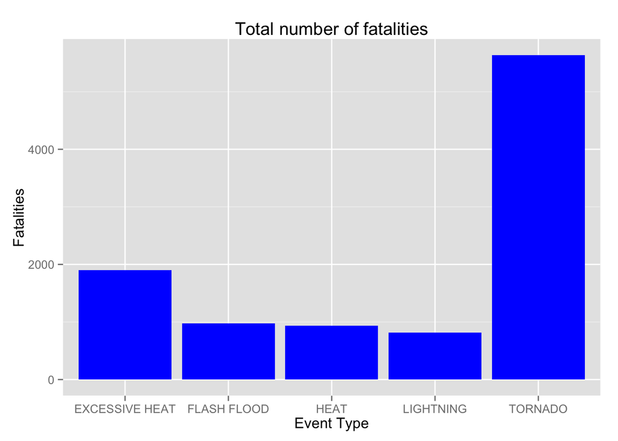

```r
library(ggplot2)
ggplot(data = max_fatalities, aes(x = max_fatalities$EVTYPE, y = max_fatalities$FATALITIES)) +
    geom_bar(fill = "blue", stat = "identity") + xlab("Event Type") + ylab("Fatalities") + ggtitle("Total number of fatalities")
```

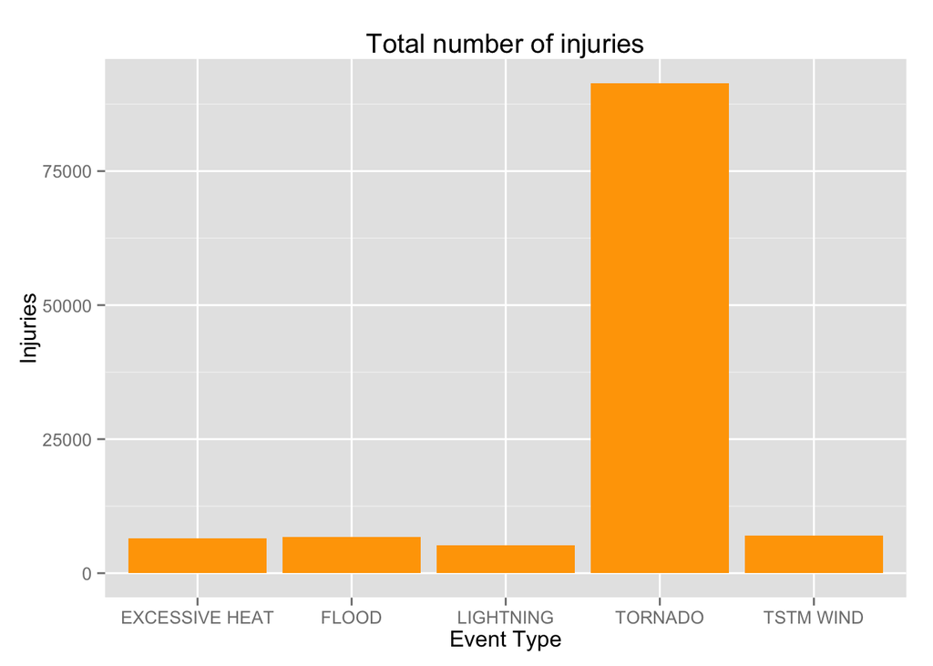

```r
ggplot(data = max_injuries, aes(x = max_injuries$EVTYPE, y = max_injuries$INJURIES)) +
    geom_bar(fill = "orange", stat = "identity") + xlab("Event Type") + ylab("Injuries") + ggtitle("Total number of injuries")
```

*Across the United States, which types of events have the greatest economic consequences?*

Aggregate data on event type and get maximum:

```r
total_damage <- aggregate(TOTALDMG ~ EVTYPE, data=clean_storm_data, FUN=sum)
total_damage <- total_damage[order(total_damage$TOTALDMG, decreasing=TRUE),]
max_damage <- total_damage[1:5,]
```

Print a plot:

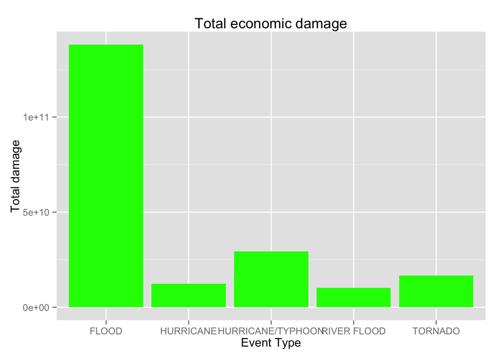

```r
ggplot(data = max_damage, aes(x = max_damage$EVTYPE, y = max_damage$TOTALDMG)) +
    geom_bar(fill = "green", stat = "identity") + xlab("Event Type") + ylab("Total damage") + ggtitle("Total economic damage")
```

As we can see the most dangorous event for public health is tornado and flood makes the biggest economic harm.